# Using the R package anticlust for stimulus selection

This document was last updated on 2019-12-11. **It is still under active construction.**

This vignette uses functionality that is currently only available in the development version of the `anticlust` package. If you would like to check out the latest features to follow this tutorial, install the development version by executing the following code:

```r
if (!"remotes" %in% rownames(installed.packages())) {
  install.packages("remotes")
}
library(remotes)
install_github("m-Py/anticlust@devel")
```

Now, load the package to reproduce the code in this tutorial:

```r
library(anticlust)
```

This tutorial teaches you how to use the `R` package `anticlust` for stimulus selection. All code can easily be reproduced via Copy & Paste if the development version of the `anticlust` package is installed. The tutorial discusses the following functionalities:

- Minimize differences between sets with regard to some variables
- Maximize differences between sets with regard to some variables
- Balance the occurrence of a categorical variable between sets
- Select a subset of the total stimulus pool – or assign each stimulus to a set

We use norming data for the open stimulus pool OASIS for this purpose (Brielmann & Pelli, 2019; Kurdi, Lozano, & Banaji, 2017). We load the data provided by Brielmann and Pelli (2019) from the internet and save the data as an `R` data frame:

```r
oasis <- read.csv("https://raw.githubusercontent.com/aenneb/OASIS-beauty/master/means_per_image.csv")
```

Let’s check out the data:

```r
head(oasis)
```

```
#>   item beauty_mean    Theme Category Valence_mean Arousal_mean beauty_SD   N
#> 1    1        4.86  Acorns1   Object         4.69         2.35  1.479893 140
#> 2    2        4.20  Acorns2   Object         4.52         2.23  1.443968 104
#> 3    3        5.16  Acorns3   Object         4.75         2.31  1.373372 368
#> 4    4        3.48 Alcohol1   Object         4.69         2.87  1.131024 145
#> 5    5        4.30 Alcohol2   Object         4.25         3.00  1.677260 104
#> 6    6        4.45 Alcohol3   Object         4.17         2.35  1.594163 104
#>    subset women_beauty_mean men_beauty_mean gender_diff_beauty  X X.1
#> 1 subset2          4.812500        4.907895          -0.095395 NA  NA
#> 2 subset4          4.592593        4.780000          -0.187407 NA  NA
#> 3 subset1          5.708791        5.994565          -0.285774 NA  NA
#> 4 subset3          4.609890        4.315217           0.294673 NA  NA
#> 5 subset4          4.314815        4.040000           0.274815 NA  NA
#> 6 subset4          4.740741        4.680000           0.060741 NA  NA
```

```r
nrow(oasis)
```

```
#> [1] 900
```

The OASIS data set contains norming data for 900 photos on arousal, valence, and beauty; so we are interested in the columns `Valence_mean`, `Arousal_mean`, `beauty_mean` to select stimulus sets.

In this tutorial, we get to know at four different procedures. The four procedures result by crossing two properties that characterize the selection of stimuli:

- The final pool of stimuli that is part of the experiment is…
  - … manually selected by the researcher; this selection is then automatically partitioned into subsets using anticlustering
  - … selected by a computer – the computer does all of the work
- The experimental manipulation is …
  - … realized via the intrinsic properties of the stimuli
  - … independent of the properties of the stimuli

# 1 The researcher decides

First, I discuss experimental designs where the final set of stimuli has already been selected by the researcher. Now, this selection has to be divided into several experimental sets. I distinguish two cases:

1. The stimulus sets have to be as similar as possible with regard to *all* response-relevant variables.
2. The groups have to differ on an independent variable, but should be as similar as possible on other variables.

## 1.1 Experimental manipulation independent of stimuli: Anticlustering

When employing an experimental manipulation that is orthogonal to the stimuli, we can use anticlustering to partition the stimulus pool into equal-sized parts that are as similar as possible. In particular, we employ *anticluster editing* to assign stimuli to sets (see Papenberg and Klau, 2019).

For this example, I preselect 200 images, namely all images that are identified as “objects” in the data base.

```r
objects <- oasis[oasis$Category == "Object", ]
```

Now I create four sets from the pool of 200 stimuli. The four sets sets should be as similar as possible with regard to the three variables arousal, valence, and beauty. I use the function `select_stimuli()` that internally calls the `anticlustering()` function (also see `?anticlustering`).

```r
# Create character vector with the relevant covariates:
covariates <- c("Valence_mean", "Arousal_mean", "beauty_mean")
stimuli <- select_stimuli(
  objects,
  equalize = covariates,
  design = 4 # specifies the number of groups
)
```

```
#> Starting stimulus selection using `Anticlustering`.
#> Selecting 4 groups, each having 50 elements from a pool of 200 stimuli.
```

The output variable `stimuli` is a data frame that has the same columns as the original input (the data frame `objects`), but has an additional column called `SET` that encodes the stimulus set that each item was assigned to.

We can use the `anticlust` function `mean_sd_tab()` to check out the quality of the results. This function prints the means and standard deviations (in brackets) of the variables of interest for each of the four stimulus sets:

```r
mean_sd_tab(stimuli[, covariates], stimuli$SET)
```

|  | Valence_mean | Arousal_mean | beauty_mean |
| --- | --- | --- | --- |
| 1 | 4.23 (0.97) | 2.83 (0.78) | 4.02 (0.99) |
| 2 | 4.23 (1.01) | 2.85 (0.81) | 4.02 (1.00) |
| 3 | 4.24 (0.96) | 2.84 (0.78) | 4.03 (0.99) |
| 4 | 4.22 (0.98) | 2.84 (0.80) | 4.04 (0.97) |

Apparently, the stimulus assignment worked quite well.

## 1.2 Experimental manipulation realized via stimuli: Min-Max Anticlustering

```r
animals <- oasis[oasis$Category == "Animal", ]
stimuli <- select_stimuli(
  animals,
  split_by = "Valence_mean",
  equalize = c("Arousal_mean"),
  design = 2 # specifies the number of groups
)
```

```
#> Starting stimulus selection using `Min-Max-Anticlustering`.
#> Selecting 2 groups, each having 67 elements from a pool of 134 stimuli.
```

```r
mean_sd_tab(stimuli[, c("Valence_mean", "Arousal_mean")], stimuli$SET)
```

|  | Valence_mean | Arousal_mean |
| --- | --- | --- |
| 1 | 5.11 (0.95) | 4.01 (0.55) |
| 2 | 3.80 (1.15) | 4.00 (0.56) |

This worked quite well. Note that the task is significantly more difficult when we also include beauty as a covariate:

```r
stimuli <- select_stimuli(
  animals,
  split_by = "Valence_mean",
  equalize = c("Arousal_mean", "beauty_mean"),
  design = 2 # specifies the number of groups
)
```

```
#> Starting stimulus selection using `Min-Max-Anticlustering`.
#> Selecting 2 groups, each having 67 elements from a pool of 134 stimuli.
```

```r
mean_sd_tab(
  stimuli[, c("Valence_mean", "Arousal_mean", "beauty_mean")],
  stimuli$SET
)
```

|  | Valence_mean | Arousal_mean | beauty_mean |
| --- | --- | --- | --- |
| 1 | 4.55 (1.43) | 4.00 (0.55) | 4.70 (1.04) |
| 2 | 4.36 (1.02) | 4.01 (0.56) | 4.71 (0.93) |

The sets are no longer very dissimilar with regard to valence. The problem is that valence is strongly correlated with beauty, as shown in the following scatter plot:

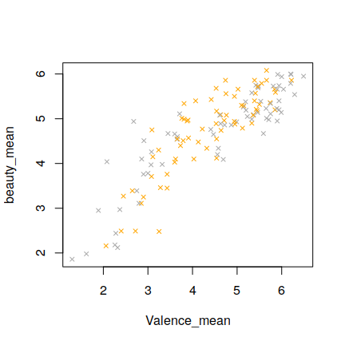

```r
plot(
  animals[, c("Valence_mean", "beauty_mean")],
  pch = 4,
  cex = 0.7,
  col = c("#a9a9a9", "orange")[stimuli$SET]
)
```

```r
cor(animals$Valence_mean, animals$beauty_mean)
```

```
#> [1] 0.8616962
```

It is more or less impossible to create sets that differ strongly on valence but are similar with regard to beauty, because these variables covary too much. Selecting item sets from a larger item pool – rather than just partitioning a preselected pool into parts – helps to ensure that the sets are more dissimilar with regard to the independent variable. This application is discussed in the next section.

# 2 The computer does all the work

In this section we discuss the case when item sets are extracted from the entire stimulus pool in an entirely automated manner – no human input required.

## 2.1 Experimental manipulation independent of stimuli: Subset anticlustering

Imagine I want to select 3 sets of stimuli that are similar with regard to all numeric variables.

```r
stimuli <- select_stimuli(
  oasis,
  equalize = c("Valence_mean", "Arousal_mean", "beauty_mean"),
  design = 3, # specifies the number of groups
  n = 100 # Number of stimuli per set
)
```

```
#> Starting stimulus selection using `Subset-Anticlustering`.
#> Selecting 3 groups, each having 100 elements from a pool of 900 stimuli.
#>
#> 0 records could be excluded due to missing values.
#> Selecting stimuli from the remaining 900 records.
```

To indicate that I do not want to partition the entire stimulus pool, but only extract a subset of the pool, I used the argument `n` – which is the size of **each** stimulus set. As the `nrow()` command confirms, our selection consists of 300 stimuli:

```r
nrow(stimuli)
```

```
#> [1] 300
```

Inspecting means and standard deviations of the variables by set shows that the stimulus assignment was successful:

```r
mean_sd_tab(
  stimuli[, c("Valence_mean", "Arousal_mean", "beauty_mean")],
  stimuli$SET
)
```

|  | Valence_mean | Arousal_mean | beauty_mean |
| --- | --- | --- | --- |
| 1 | 4.79 (1.12) | 3.44 (0.87) | 4.54 (1.10) |
| 2 | 4.79 (1.12) | 3.44 (0.87) | 4.54 (1.10) |
| 3 | 4.79 (1.12) | 3.44 (0.88) | 4.54 (1.10) |

Hard to beat those results.

## 2.2 Experimental manipulation realized via stimuli: Subset Min-Max-Anticlustering

In this section, I select item sets that differ with regard to valence, but are similar with regard to arousal and beauty. I select 3 sets á 40 items from the entire pool of 900 items:

```r
stimuli <- select_stimuli(
  oasis,
  split_by = "Valence_mean",
  equalize = c("Arousal_mean", "beauty_mean"),
  design = 3, # specifies the number of groups
  n = 40 # Number of stimuli per set
)
```

```
#> Starting stimulus selection using `Subset-Min-Max-Anticlustering`.
#> Selecting 3 groups, each having 40 elements from a pool of 900 stimuli.
#>
#> 0 records could be excluded due to missing values.
#> Selecting stimuli from the remaining 900 records.
```

```r
mean_sd_tab(
  stimuli[, c("Valence_mean", "Arousal_mean", "beauty_mean")],
  stimuli$SET
)
```

|  | Valence_mean | Arousal_mean | beauty_mean |
| --- | --- | --- | --- |
| 1 | 2.75 (0.65) | 4.37 (0.62) | 4.58 (0.66) |
| 2 | 5.41 (0.41) | 4.36 (0.62) | 4.62 (0.64) |
| 3 | 4.37 (0.91) | 4.35 (0.60) | 4.58 (0.64) |

Visualizing this selection is interesting. The following panel illustrates the pairwise scatter plots:

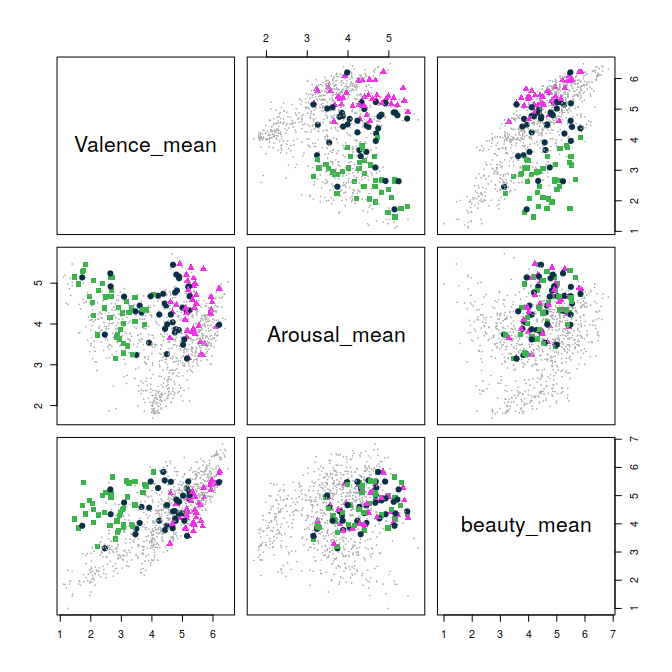

```r
# Illustrate final stimulus selection
was_selected <- oasis$item %in% stimuli$item
group <- rep(1, nrow(oasis))
group[was_selected] <- stimuli$SET + 1


colors <- c("#a9a9a9", "#3cb44b", "#f032e6", "#093145")
cex <-  c(0.1, rep(1.1, 3))
pch <- c(4, 15, 17, 19)
plot(
  oasis[, c("Valence_mean", "Arousal_mean", "beauty_mean")],
  col = colors[group],
  cex = cex[group],
  pch = pch[group]
)
```

Small grey symbols indicate that an image has not been selected; large colored dots illustrate images that have been selected. We recognize the following properties of our selection:

- Even thought it is very difficult to obtain sets that differ on valence but are similar on beauty – the two variables are strongly correlated – the program did it (see the scatter plot of beauty and valence in the lower left or upper right)
- There is actually overlap in valence between the sets. The neutral condition also contains some very positive and very negative images. Using a Divide and Select approach (see below), there would not have been any overlap on valence
- The three sets overlap strongly on the variables beauty and arousal, as they should

## 2.3 Divide and Select

The `divide_and_select()` function can also be used to create groups that differ on an independent variable. It works by actually dividing the item pool on this variable using a hard cutoff. It works as follows:

```r
stimuli <- divide_and_select(
  oasis,
  split_by = "Valence_mean",
  equalize = c("Arousal_mean", "beauty_mean"),
  design = 3, # specifies the number of groups
  n = 40 # Number of stimuli per set
)
```

```
#> Starting stimulus selection using `Divide and Select`.
#> Selecting 3 groups, each having 40 elements from a pool of 900 stimuli.
```

```r
mean_sd_tab(
  stimuli[, c("Valence_mean", "Arousal_mean", "beauty_mean")],
  stimuli$SET
)
```

|  | Valence_mean | Arousal_mean | beauty_mean |
| --- | --- | --- | --- |
| 1 | 4.54 (0.29) | 3.84 (0.83) | 4.51 (0.75) |
| 2 | 5.38 (0.31) | 3.82 (0.83) | 4.52 (0.73) |
| 3 | 3.20 (0.53) | 3.83 (0.82) | 4.50 (0.74) |

Let’s also visualize this selection:

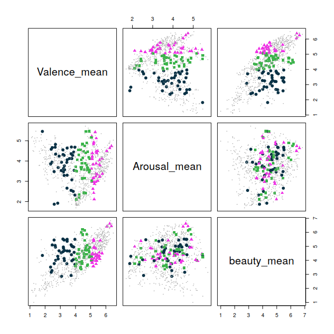

```r
was_selected <- oasis$item %in% stimuli$item
group <- rep(1, nrow(oasis))
group[was_selected] <- stimuli$SET + 1

plot(
  oasis[, c("Valence_mean", "Arousal_mean", "beauty_mean")],
  col = colors[group],
  cex = cex[group],
  pch = pch[group]
)
```

With the Divide and Select method, there is no overlap in valence between the different sets – they were actually “divided” by valence. However, in total, the dissimilarity with regard to valence (based on the mean difference between) is lower than in the example above. Hence, I would suggest to try out the Min-Max-Anticlustering approach first (using the function `select_stimuli()`) as it tends to better maximize differences between the `split` variable while also ensuring that the covariates are balanced. However, the choice is entirely left to you; it is probably best to try out both methods.

### 2.3.1 Divide by categorical variable

In the previous example, valence was artificially categorized to serve as a grouping variable. Sometimes, a truly categorical variable should serve a the grouping variable. As an example, each of the images in the data base belongs to one of four categories. The frequency of each category is given as follows:

```r
table(oasis$Category)
```

```
#>
#> Animal Object Person  Scene
#>    134    200    346    220
```

```r
stimuli <- divide_and_select(
  oasis,
  split_by = "Category",
  equalize = c("Arousal_mean", "Valence_mean"),
  design = 4, # specifies the number of groups
  n = 40 # Number of stimuli per set
)
```

```
#> Starting stimulus selection using `Divide and Select`.
#> Selecting 4 groups, each having 40 elements from a pool of 900 stimuli.
```

```r
mean_sd_tab(stimuli[, c("Arousal_mean", "Valence_mean")], stimuli$SET)
```

|  | Arousal_mean | Valence_mean |
| --- | --- | --- |
| 1 | 3.53 (0.70) | 4.37 (1.27) |
| 2 | 3.56 (0.72) | 4.41 (1.26) |
| 3 | 3.61 (0.68) | 4.39 (1.27) |
| 4 | 3.56 (0.71) | 4.38 (1.27) |

Apparently, this worked quite well. Let’s also confirm that the `Category` variable is cleanly split between the four sets:

```r
table(stimuli$Category, stimuli$SET)
```

```
#>
#>           1  2  3  4
#>   Animal  0  0 40  0
#>   Object 40  0  0  0
#>   Person  0 40  0  0
#>   Scene   0  0  0 40
```

### 2.3.2 Divide and Select Reloaded

Using the functionality to pass categorical variables to the `divide_and_select()` function, we can try to select item sets that differ more strongly with regard to an independent variable. To this end, I apply customized cutoffs above (and below) which the valence levels are defined. I use the function `case_when()` from the package `dplyr`:

```r
library(dplyr)
oasis$category_valence <- case_when(
  oasis$Valence_mean < 3 ~ "low",
  oasis$Valence_mean > 3.5 & oasis$Valence_mean < 4.5 ~ "neutral",
  oasis$Valence_mean > 5 ~ "high",
  TRUE ~ "" # default case: exclude those
)

# exclude cases that are not within one of the ranges
oasis_subset <- oasis[oasis$category_valence != "", ]

# Check out number of preselected items:
nrow(oasis_subset)
```

```
#> [1] 695
```

```r
# Do Divide and Select
stimuli <- divide_and_select(
  oasis_subset,
  split_by = "category_valence",
  equalize = c("Arousal_mean", "beauty_mean"),
  design = 3, # specifies the number of groups
  n = 40 # Number of stimuli per set
)
```

```
#> Starting stimulus selection using `Divide and Select`.
#> Selecting 3 groups, each having 40 elements from a pool of 695 stimuli.
```

```r
mean_sd_tab(
  stimuli[, c("Valence_mean", "Arousal_mean", "beauty_mean")],
  stimuli$SET
)
```

|  | Valence_mean | Arousal_mean | beauty_mean |
| --- | --- | --- | --- |
| 1 | 4.00 (0.30) | 3.77 (0.79) | 4.25 (0.77) |
| 2 | 5.34 (0.28) | 3.78 (0.80) | 4.49 (0.61) |
| 3 | 2.56 (0.29) | 3.86 (0.80) | 3.99 (0.82) |

Let’s also visualize this selection:

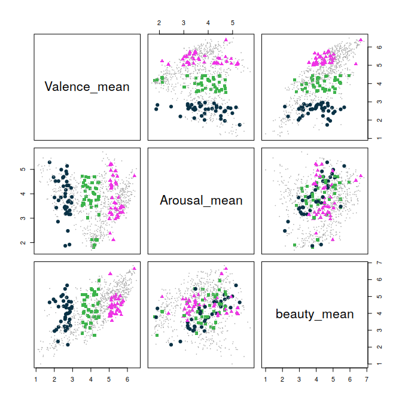

```r
was_selected <- oasis$item %in% stimuli$item
group <- rep(1, nrow(oasis))
group[was_selected] <- stimuli$SET + 1

plot(
  oasis[, c("Valence_mean", "Arousal_mean", "beauty_mean")],
  col = colors[group],
  cex = cex[group],
  pch = pch[group]
)
```

Using this strategy, you can decide for yourself which level of deviation between the covariates is still acceptable, while increasing the difference between sets with regard to the independent variable.

The function `select_stimuli()` tends to favor the similarity with regard to the covariates, and tries to maximize differences with regard to the independent variable as long as the covariates remain similar.

## 2.4 Balancing a categorical variable

The function `select_stimuli()` also allows to balance the frequency of a categorical variable between stimulus sets via the argument `balance`. This argument takes as input the names of the columns that should be balanced across sets.

In the following examples, I repeat the four cases from above and use balance the image category across sets each time.

### 2.4.1 Anticlustering

Create sets that are maximally similar with regard to valence, arousal and beauty from a random preselection (i.e., classical anticlustering), and the category is balanced between sets:

```r
# Preselect 200 random stimuli
preselection <- oasis[sample(nrow(oasis), size = 200), ]
# Create character vector with the relevant covariates:
stimuli <- select_stimuli(
  preselection,
  equalize = c("Valence_mean", "Arousal_mean", "beauty_mean"),
  design = 3,
  balance = "Category"
)
```

```
#> Starting stimulus selection using `Anticlustering`.
#> Selecting 3 groups, each having 66 or 67 elements from a pool of 200 stimuli.
```

```r
# Check out that the category is balanced:
table(stimuli$SET, stimuli$Category)
```

```
#>
#>     Animal Object Person Scene
#>   1      9     14     28    16
#>   2      8     14     28    17
#>   3      9     13     28    16
```

```r
# Check M/SD by set
mean_sd_tab(stimuli[, c("Valence_mean", "Arousal_mean", "beauty_mean")], stimuli$SET)
```

|  | Valence_mean | Arousal_mean | beauty_mean |
| --- | --- | --- | --- |
| 1 | 4.33 (1.21) | 3.62 (0.84) | 4.35 (1.11) |
| 2 | 4.32 (1.21) | 3.63 (0.83) | 4.34 (1.13) |
| 3 | 4.33 (1.19) | 3.63 (0.81) | 4.34 (1.06) |

Note that by including an additional restriction (i.e., balancing out a variable between sets), we make it harder for `anticlust` to find sets that are balanced on the covariates. The results are expected to be better if no such restriction is included. However, the results in this case are still pretty good.

This is a general rule: More restrictions are less easy to satisfy. If we additionally require that one variable differs between sets, it becomes even harder to balance the covariates between sets. However, `anticlust` will give its best!

### 2.4.2 Min-Max Anticlustering

Create sets that differ on valence, are similar with regard to arousal, and the category is balanced between sets:

```r
# Preselect 200 random stimuli
preselection <- oasis[sample(nrow(oasis), size = 200), ]
stimuli <- select_stimuli(
  preselection,
  split_by = "Valence_mean",
  equalize = "Arousal_mean",
  design = 3,
  balance = "Category"
)
```

```
#> Starting stimulus selection using `Min-Max-Anticlustering`.
#> Selecting 3 groups, each having 66 or 67 elements from a pool of 200 stimuli.
```

```r
# Check out that the category is balanced:
table(stimuli$SET, stimuli$Category)
```

```
#>
#>     Animal Object Person Scene
#>   1     11     14     25    17
#>   2     11     15     25    16
#>   3     11     14     24    17
```

```r
# Check M/SD by set
mean_sd_tab(stimuli[, c("Valence_mean", "Arousal_mean")], stimuli$SET)
```

|  | Valence_mean | Arousal_mean |
| --- | --- | --- |
| 1 | 4.36 (1.02) | 3.65 (0.82) |
| 2 | 3.37 (1.09) | 3.64 (0.81) |
| 3 | 5.32 (0.80) | 3.68 (0.80) |

### 2.4.3 Subset Anticlustering

Create sets that are maximally similar with regard to valence, arousal and beauty. Extract three sets with 50 items each from the entire pool of 900 items; the category is balanced between sets:

```r
stimuli <- select_stimuli(
  oasis,
  equalize = c("Valence_mean", "Arousal_mean", "beauty_mean"),
  design = 3,
  balance = "Category",
  n = 50
)
```

```
#> Starting stimulus selection using `Subset-Anticlustering`.
#> Selecting 3 groups, each having 50 elements from a pool of 900 stimuli.
#>
#> 0 records could be excluded due to missing values.
#> Selecting stimuli from the remaining 900 records.
```

```r
# Check out that the category is balanced:
table(stimuli$SET, stimuli$Category)
```

```
#>
#>     Animal Object Person Scene
#>   1      2     19     22     7
#>   2      2     19     22     7
#>   3      2     19     22     7
```

```r
# Check M/SD by set
mean_sd_tab(stimuli[, c("Valence_mean", "Arousal_mean", "beauty_mean")], stimuli$SET)
```

|  | Valence_mean | Arousal_mean | beauty_mean |
| --- | --- | --- | --- |
| 1 | 4.87 (0.91) | 3.33 (1.04) | 4.47 (1.10) |
| 2 | 4.87 (0.91) | 3.33 (1.04) | 4.46 (1.10) |
| 3 | 4.87 (0.91) | 3.33 (1.04) | 4.47 (1.10) |

### 2.4.4 Subset Min-Max Anticlustering

Create sets that are maximally similar with regard to arousal and beauty, maximize difference with regard to valence. Extract three sets with 50 items each from the entire pool of 900 items; the category is balanced between sets:

```r
stimuli <- select_stimuli(
  oasis,
  split_by = "Valence_mean",
  equalize = c("Arousal_mean", "beauty_mean"),
  design = 3,
  balance = "Category",
  n = 50
)
```

```
#> Starting stimulus selection using `Subset-Min-Max-Anticlustering`.
#> Selecting 3 groups, each having 50 elements from a pool of 900 stimuli.
#>
#> 0 records could be excluded due to missing values.
#> Selecting stimuli from the remaining 900 records.
```

```r
# Check out that the category is balanced:
table(stimuli$SET, stimuli$Category)
```

```
#>
#>     Animal Object Person Scene
#>   1      5      3     23    19
#>   2      5      3     23    19
#>   3      5      3     23    19
```

```r
# Check M/SD by set
mean_sd_tab(stimuli[, c("Valence_mean", "Arousal_mean", "beauty_mean")], stimuli$SET)
```

|  | Valence_mean | Arousal_mean | beauty_mean |
| --- | --- | --- | --- |
| 1 | 5.23 (0.66) | 3.97 (0.65) | 4.52 (0.93) |
| 2 | 4.17 (1.00) | 3.96 (0.66) | 4.50 (0.95) |
| 3 | 3.18 (0.77) | 3.98 (0.66) | 4.48 (0.94) |

## 2.5 References

Brielmann, A. A., & Pelli, D. (2019). Intense beauty requires intense pleasure. *Frontiers in Psychology, 10*, 1–17.

Kurdi, B., Lozano, S., & Banaji, M. R. (2017). Introducing the Open Affective Standardized Image Set (OASIS). *Behavior Research Methods, 49*, 457–470.

Papenberg, M., & Klau, G. W. (2019, October 30). Using anticlustering to partition a stimulus pool into equivalent parts. https://doi.org/10.31234/osf.io/3razc. Preprint submitted for publication.